# Designing, Running, and Analyzing Experiments

##### Using GLM for poisson distributed data

**When the underlying data does not follow a normal distribution**

Previously, we had run Anova tests on Normally distributed data Using GLM, you can run Anova on data that is not normally distributed

In the example below, we will be looking at eror count data that follows a poisson distribution

Case study: You have rolled 2 different versions of the user profile page and you want to see how many users have errors entering their details on the page. We will compare results of the 2 new versions with the existing version

```
Poisson distribution is widely seen for count data.

The Poisson distribution may be useful to model events such as
* The number of meteorites greater than 1 meter diameter that strike Earth in a year
* The number of patients arriving in an emergency room between 10 and 11 pm
* In a laser the number of photons hitting a detector in a particular time interval will follow Poisson distribution.

In our example, poisson is a candidate distribution because
* Errors are discrete
* We assume that occurrence of one error does not affect the probability that a second error will occur
* Users cannot make 2 errors at the same time

https://en.wikipedia.org/wiki/Poisson_distribution
```

```r
error_count <- read.csv("error_count.csv")
error_count$Design <- factor(error_count$Design, levels=c("Orig","New1","New2"))

ddply(error_count, ~ Design, function(data) summary(data$Errors))
```

```
##   Design Min. 1st Qu. Median Mean 3rd Qu. Max.
## 1   Orig    1    2.00    2.5 2.50    3.00    4
## 2   New1    0    0.00    0.5 0.70    1.00    2
## 3   New2    2    3.75    5.0 5.05    6.25    9
```

```r
ddply(error_count, ~ Design, summarise, Errors.mean=mean(Errors), Errors.sd=sd(Errors))
```

```
##   Design Errors.mean Errors.sd
## 1   Orig        2.50 1.0513150
## 2   New1        0.70 0.8013147
## 3   New2        5.05 1.9049796
```

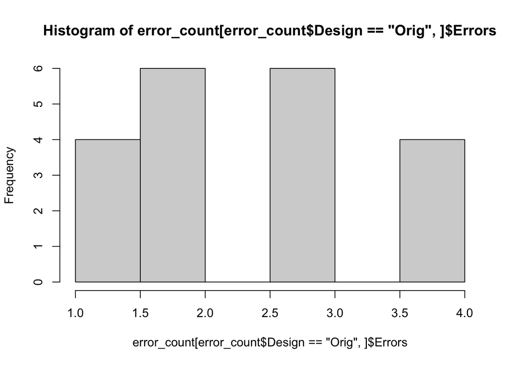

```r
hist(error_count[error_count$Design == "Orig",]$Errors)
```

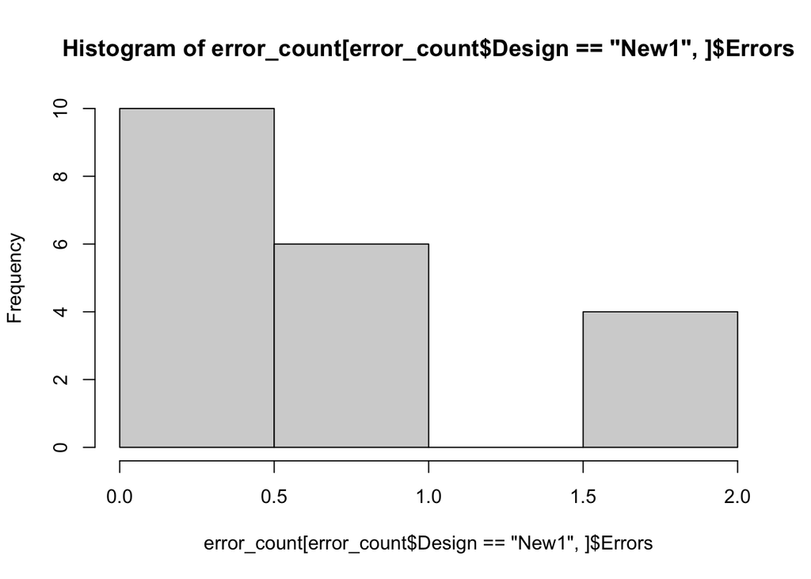

```r
hist(error_count[error_count$Design == "New1",]$Errors)
```

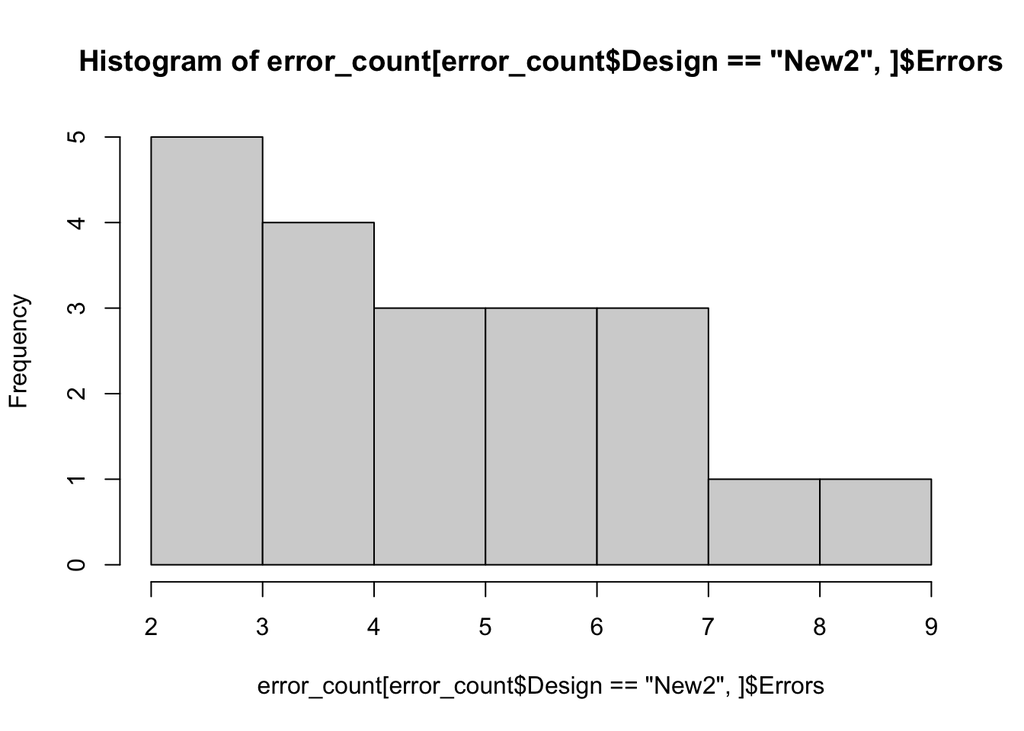

```r
hist(error_count[error_count$Design == "New2",]$Errors)
```

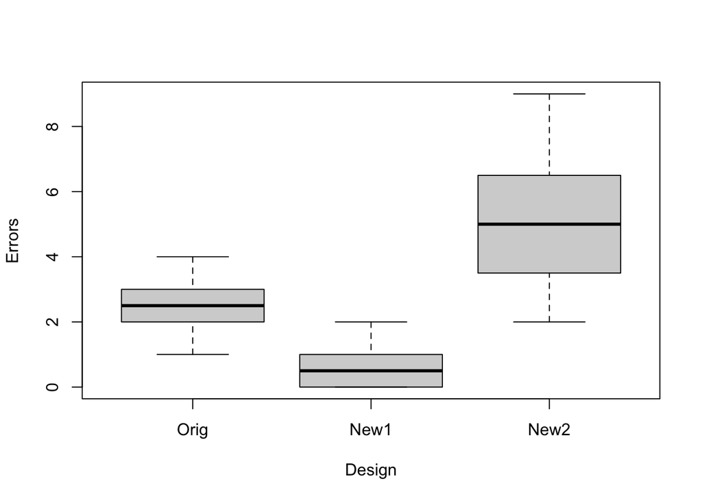

```r
plot(Errors ~ Design, data=error_count) # boxplot
```

```r
# re-verify that these data are Poisson-distributed
library(fitdistrplus)
fit = fitdist(error_count[error_count$Design == "Orig",]$Errors, "pois", discrete=TRUE)
gofstat(fit) # goodness-of-fit test
```

```
## Chi-squared statistic:  1.522232
## Degree of freedom of the Chi-squared distribution:  2
## Chi-squared p-value:  0.4671449
##    the p-value may be wrong with some theoretical counts < 5
## Chi-squared table:
##      obscounts theocounts
## <= 1  4.000000   5.745950
## <= 2  6.000000   5.130312
## <= 3  6.000000   4.275260
## > 3   4.000000   4.848477
##
## Goodness-of-fit criteria
##                                1-mle-pois
## Akaike's Information Criterion   65.61424
## Bayesian Information Criterion   66.60997
```

```r
fit = fitdist(error_count[error_count$Design == "New1",]$Errors, "pois", discrete=TRUE)
gofstat(fit) # goodness-of-fit test
```

```
## Chi-squared statistic:  0.3816087
## Degree of freedom of the Chi-squared distribution:  1
## Chi-squared p-value:  0.5367435
##    the p-value may be wrong with some theoretical counts < 5
## Chi-squared table:
##      obscounts theocounts
## <= 0 10.000000   9.931706
## <= 1  6.000000   6.952194
## > 1   4.000000   3.116100
##
## Goodness-of-fit criteria
##                                1-mle-pois
## Akaike's Information Criterion   45.53208
## Bayesian Information Criterion   46.52781
```

```r
fit = fitdist(error_count[error_count$Design == "New2",]$Errors, "pois", discrete=TRUE)
gofstat(fit) # goodness-of-fit test
```

```
## Chi-squared statistic:  0.1611327
## Degree of freedom of the Chi-squared distribution:  3
## Chi-squared p-value:  0.9836055
##    the p-value may be wrong with some theoretical counts < 5
## Chi-squared table:
##      obscounts theocounts
## <= 3  5.000000   5.161546
## <= 4  4.000000   3.473739
## <= 5  3.000000   3.508476
## <= 6  3.000000   2.952967
## > 6   5.000000   4.903272
##
## Goodness-of-fit criteria
##                                1-mle-pois
## Akaike's Information Criterion   84.19266
## Bayesian Information Criterion   85.18839
```

```r
# analyze using Poisson regression
# set sum-to-zero contrasts for the Anova call
contrasts(error_count$Design) <- "contr.sum"
# family parameter identifies both distribution and link fn
m = glm(Errors ~ Design, data=error_count, family=poisson)
Anova(m, type=3)
```

```
## Analysis of Deviance Table (Type III tests)
##
## Response: Errors
##        LR Chisq Df Pr(>Chisq)
## Design    74.93  2  < 2.2e-16 ***
## ---
## Signif. codes:  0 '***' 0.001 '**' 0.01 '*' 0.05 '.' 0.1 ' ' 1
```

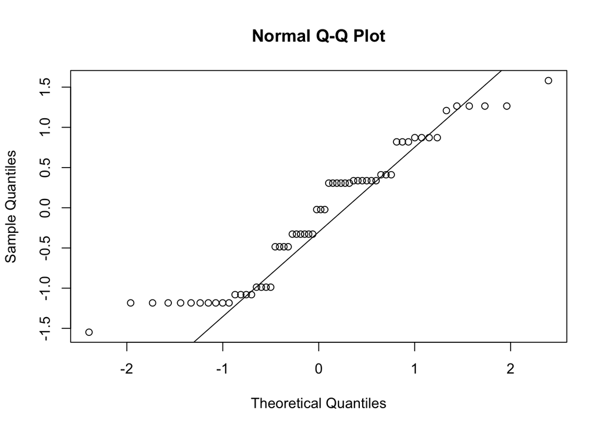

```r
qqnorm(residuals(m)); qqline(residuals(m)) # s'ok! Poisson regression makes no normality assumption
```

```r
# conduct pairwise comparisons among levels of Design
library(multcomp)
summary(glht(m, mcp(Design="Tukey")), test=adjusted(type="holm")) # Tukey means compare all pairs
```

```
##
##   Simultaneous Tests for General Linear Hypotheses
##
## Multiple Comparisons of Means: Tukey Contrasts
##
##
## Fit: glm(formula = Errors ~ Design, family = poisson, data = error_count)
##
## Linear Hypotheses:
##                  Estimate Std. Error z value Pr(>|z|)
## New1 - Orig == 0  -1.2730     0.3024  -4.210 5.11e-05 ***
## New2 - Orig == 0   0.7031     0.1729   4.066 5.11e-05 ***
## New2 - New1 == 0   1.9761     0.2852   6.929 1.27e-11 ***
## ---
## Signif. codes:  0 '***' 0.001 '**' 0.01 '*' 0.05 '.' 0.1 ' ' 1
## (Adjusted p values reported -- holm method)
```